# CarPrices Analysis

November 10, 2018

### Background

As a part of the car prices dataset, I am trying to determine what could explain the two separate lines for the Cadillac Deville in the graphic below.

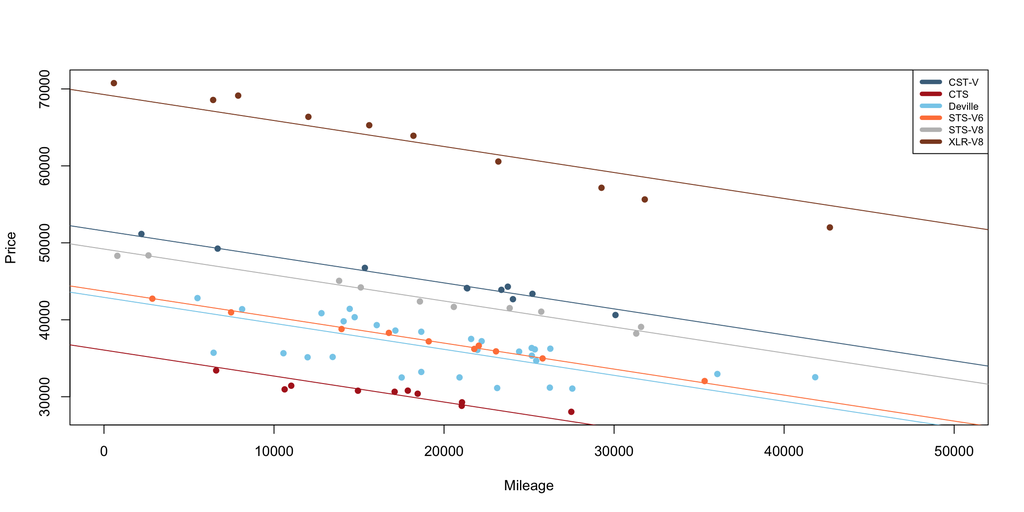

In order to do this I will test a couple different variables and see if there is a correlation between those variables and the points that are represented. I will not use any interactions for the variables in my graphs. Since I am simply finding what correlates and not doing a test, I will not be using a hypothesis, but typically the hypothesis for a multiple regression is as follows:

$$\underbrace{Y_i}_{\text{Price}} = \overbrace{\beta_0 + \beta_1 \underbrace{X_{i1}}_{\text{Mileage}}}^{\text{Intercept and Slope}} + \overbrace{\beta_2 \underbrace{X_{i2}}_{\text{1 if Deville}}}^{\text{Cadillac Deville Adjustments to Line}} + \epsilon_i$$

### Analysis

```
##
## Call:
## lm(formula = Price ~ Mileage + Trim, data = Deville_dat)
##
## Residuals:
##     Min      1Q  Median      3Q     Max
## -1199.2  -460.1   102.2   468.4  1354.8
##
## Coefficients:
##                    Estimate Std. Error t value Pr(>|t|)
## (Intercept)       4.371e+04  3.874e+02 112.820  < 2e-16 ***
## Mileage          -3.077e-01  1.585e-02 -19.419  < 2e-16 ***
## TrimDTS Sedan 4D  8.039e+02  3.058e+02   2.628   0.0142 *
## TrimSedan 4D     -4.953e+03  3.082e+02 -16.068  5.1e-15 ***
## ---
## Signif. codes:  0 '***' 0.001 '**' 0.01 '*' 0.05 '.' 0.1 ' ' 1
##
## Residual standard error: 682.8 on 26 degrees of freedom
## Multiple R-squared:  0.9617, Adjusted R-squared:  0.9572
## F-statistic: 217.4 on 3 and 26 DF,  p-value: < 2.2e-16
```

When looking at the multiple r squared as well as the p value of all of the intercepts and slopes, the summary shows that they are all significant and since the r squared multiple is close to one, that means that the lines and the data are also highly correlated.

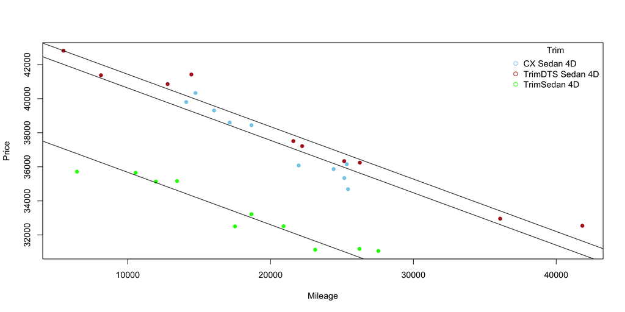

```r
palette(c("skyblue","firebrick","green"))
plot(Price ~ Mileage, data = Deville_dat, pch = 16, col = Trim)
legend("topright", legend=c("CX Sedan 4D","TrimDTS Sedan 4D", "TrimSedan 4D"), pch=1, col=palette(), title="Trim", bty="n")

abline(my_lm$coef[1],my_lm$coef[2])
abline(my_lm$coef[1] + my_lm$coef[3], my_lm$coef[2])
abline(my_lm$coef[1] + my_lm$coef[4], my_lm$coef[2])
```

As can be seen above, the trim is the best fit for the multiple lines that the Deville had.

```
##
## Call:
## lm(formula = Price ~ Mileage + Sound, data = Deville_dat)
##
## Residuals:
##    Min     1Q Median     3Q    Max
##  -4670  -2085   1048   1967   3786
##
## Coefficients:
##               Estimate Std. Error t value Pr(>|t|)
## (Intercept)  4.127e+04  1.295e+03  31.858  < 2e-16 ***
## Mileage     -2.340e-01  6.125e-02  -3.820 0.000711 ***
## Sound       -1.204e+03  1.042e+03  -1.155 0.258245
## ---
## Signif. codes:  0 '***' 0.001 '**' 0.01 '*' 0.05 '.' 0.1 ' ' 1
##
## Residual standard error: 2651 on 27 degrees of freedom
## Multiple R-squared:  0.3997, Adjusted R-squared:  0.3552
## F-statistic: 8.987 on 2 and 27 DF,  p-value: 0.00102
```

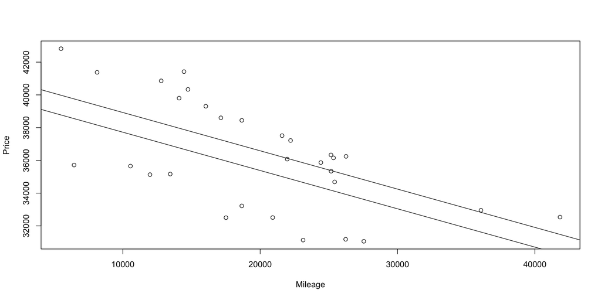

To prove my point that trim is the best fit, I tried to include another variable and see how well it fits. In this case I chose to fit the sound, but as can be seen above, that is not as good of a fit as the lines for the trim. Also, the r squared multiple is closer to 0, (currently at .3997) which means that this variable is not as correlated to the points on the graph.

### Interpretation

There are three types of trim on the Deville and these three types of trim best fit the lines for the Deville Model as can be seen above.